# Practical Machine Learning

Pradeep Senapati

April 11, 2018

**Introduction**

Using devices such as Jawbone Up, Nike FuelBand, and Fitbit it is now possible to collect a large amount of data about personal activity relatively inexpensively. These type of devices are part of the quantified self movement - a group of enthusiasts who take measurements about themselves regularly to improve their health, to find patterns in their behavior, or because they are tech geeks. One thing that people regularly do is quantify how much of a particular activity they do, but they rarely quantify how well they do it. In this project, your goal will be to use data from accelerometers on the belt, forearm, arm, and dumbell of 6 participants. They were asked to perform barbell lifts correctly and incorrectly in 5 different ways. More information is available from the website here: http://groupware.les.inf.puc-rio.br/har (see the section on the Weight Lifting Exercise Dataset).

The project can be found on github: http://benakiva.github.io/practicalML/ and https://github.com/benakiva/practicalML

**Data Source**

The training data for this project are available here:

https://d396qusza40orc.cloudfront.net/predmachlearn/pml-training.csv

The test data are available here:

https://d396qusza40orc.cloudfront.net/predmachlearn/pml-testing.csv

The data for this project come from this source: http://groupware.les.inf.puc-rio.br/har.

**Loading the Dataset**

Files were downloaded from the URLs offline outside the program. Data from the downloaded files are loaded to dt_training and dt_testing data frames.

```r
library(plyr)
```

```r
library(ggplot2)
library(caret)
library(rpart)
library(rpart.plot)
library(RColorBrewer)
library(rattle)
library(randomForest)
library(gbm)
library(gdata)
setwd ("C:/Pradeep/Data Science/Practical Machine Learning")
```

```r
# Load the training dataset
dt_training <- read.csv("C:/Pradeep/Data Science/Practical Machine Learning/pml-training.csv")
# Load the testing dataset
dt_testing <- read.csv("C:/Pradeep/Data Science/Practical Machine Learning/pml-testing.csv")
```

**Cleaning Data**

Removed all columns that contains NA and features that are not in the testing dataset. The features containing NA are the variance, mean and standard devition (SD) within each window for each feature. Since the testing dataset has no time-dependence, these values are useless and can be disregarded. Also removed the first 7 features since they are related to the time-series or are not numeric.

```r
features <- names(dt_testing[,colSums(is.na(dt_testing)) == 0])[8:59]

# Only use features used in testing cases.
dt_training <- dt_training[,c(features,"classe")]
dt_testing <- dt_testing[,c(features,"problem_id")]

dim(dt_training)
```

```
## [1] 19622    53
```

```r
dim(dt_testing)
```

```
## [1] 20 53
```

**Partitioning the Dataset**

Data is split into a training data set (60% of the total cases) and a testing data set (40% of the total cases); the latter should not be confused with the data in the pml-testing.csv file). This will allow us to estimate the out of sample error of our predictor.

```r
inTrain <- createDataPartition(dt_training$classe, p=0.6, list=FALSE)
training <- dt_training[inTrain,]
testing <- dt_training[-inTrain,]

dim(training)
```

```
## [1] 11776    53
```

```r
dim(testing)
```

```
## [1] 7846   53
```

**Building the Decision Tree Model**

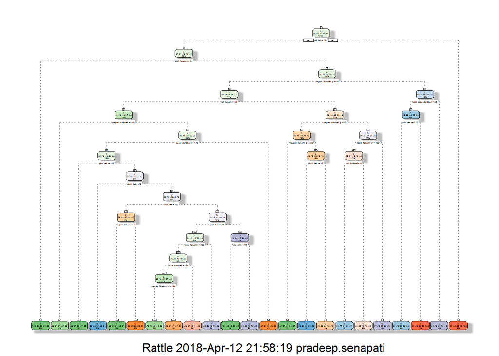

```r
set.seed(12345)
modFitDT <- rpart(classe ~ ., data = training, method="class", control = rpart.control(method = "cv", number = 10))
fancyRpartPlot(modFitDT)
```

**Predicting with the Decision Tree Model**

```r
library(e1071)
set.seed(12345)
prediction <- predict(modFitDT, testing, type = "class")
confusionMatrix(prediction, testing$classe)
```

```
## Confusion Matrix and Statistics
##
##           Reference
## Prediction    A    B    C    D    E
##          A 2057  320   22  159   64
##          B   54  803   75   28   81
##          C   49  137 1080  181  192
##          D   25  100  100  815   70
##          E   47  158   91  103 1035
##
## Overall Statistics
##
##                Accuracy : 0.738
##                  95% CI : (0.7281, 0.7477)
##     No Information Rate : 0.2845
##     P-Value [Acc > NIR] : < 2.2e-16
##
##                   Kappa : 0.6666
##  Mcnemar's Test P-Value : < 2.2e-16
##
## Statistics by Class:
##
##                      Class: A Class: B Class: C Class: D Class: E
## Sensitivity            0.9216   0.5290   0.7895   0.6337   0.7178
## Specificity            0.8994   0.9624   0.9137   0.9550   0.9377
## Pos Pred Value         0.7845   0.7714   0.6589   0.7342   0.7218
## Neg Pred Value         0.9665   0.8949   0.9536   0.9301   0.9365
## Prevalence             0.2845   0.1935   0.1744   0.1639   0.1838
## Detection Rate         0.2622   0.1023   0.1376   0.1039   0.1319
## Detection Prevalence   0.3342   0.1327   0.2089   0.1415   0.1828
## Balanced Accuracy      0.9105   0.7457   0.8516   0.7944   0.8277
```

**Building the Random Forest Model**

Using random forest, the out of sample error should be small. The error will be estimated using the 40% testing sample. We should expect an error estimate of < 3%.

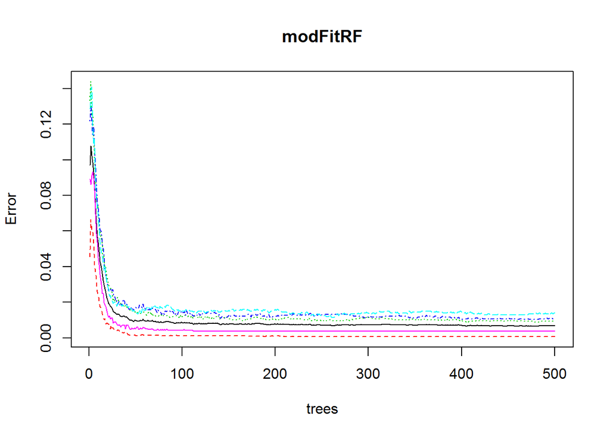

```r
set.seed(12345)
modFitRF <- randomForest(classe ~ ., data = training, method = "rf", importance = T, trControl = trainControl(method = "cv", classProbs=TRUE,savePredictions=TRUE,allowParallel=TRUE, number = 10))
plot(modFitRF)
```

**Building the Boosting Model**

```r
modFitBoost <- train(classe ~ ., method = "gbm", data = training,
                    verbose = F,
                    trControl = trainControl(method = "cv", number = 10))

modFitBoost
```

```
## Stochastic Gradient Boosting
##
## 11776 samples
##    52 predictor
##     5 classes: 'A', 'B', 'C', 'D', 'E'
##
## No pre-processing
## Resampling: Cross-Validated (10 fold)
## Summary of sample sizes: 10598, 10597, 10600, 10598, 10599, 10598, ...
## Resampling results across tuning parameters:
##
##   interaction.depth  n.trees  Accuracy   Kappa
##   1                   50      0.7543387  0.6884962
##   1                  100      0.8243923  0.7776711
##   1                  150      0.8575103  0.8196443
##   2                   50      0.8581036  0.8201741
##   2                  100      0.9101607  0.8863344
##   2                  150      0.9318987  0.9138315
##   3                   50      0.8974219  0.8701605
##   3                  100      0.9420887  0.9267161
##   3                  150      0.9612795  0.9510100
##
## Tuning parameter 'shrinkage' was held constant at a value of 0.1
##
## Tuning parameter 'n.minobsinnode' was held constant at a value of 10
## Accuracy was used to select the optimal model using the largest value.
## The final values used for the model were n.trees = 150,
##  interaction.depth = 3, shrinkage = 0.1 and n.minobsinnode = 10.
```

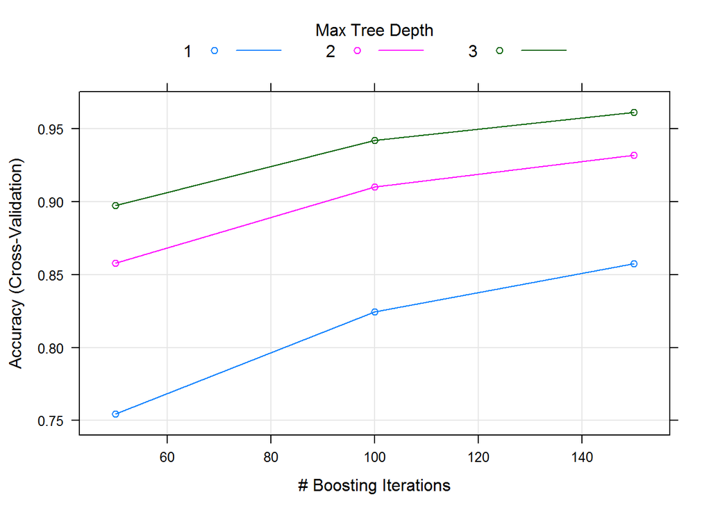

```r
plot(modFitBoost)
```

**Predicting with the Random Forest Model**

```r
prediction <- predict(modFitRF, testing, type = "class")
confusionMatrix(prediction, testing$classe)
```

```
## Confusion Matrix and Statistics
##
##           Reference
## Prediction    A    B    C    D    E
##          A 2229   13    0    0    0
##          B    2 1500    6    0    0
##          C    0    5 1360   18    1
##          D    0    0    2 1267    4
##          E    1    0    0    1 1437
##
## Overall Statistics
##
##                Accuracy : 0.9932
##                  95% CI : (0.9912, 0.9949)
##     No Information Rate : 0.2845
##     P-Value [Acc > NIR] : < 2.2e-16
##
##                   Kappa : 0.9915
##  Mcnemar's Test P-Value : NA
##
## Statistics by Class:
##
##                      Class: A Class: B Class: C Class: D Class: E
## Sensitivity            0.9987   0.9881   0.9942   0.9852   0.9965
## Specificity            0.9977   0.9987   0.9963   0.9991   0.9997
## Pos Pred Value         0.9942   0.9947   0.9827   0.9953   0.9986
## Neg Pred Value         0.9995   0.9972   0.9988   0.9971   0.9992
## Prevalence             0.2845   0.1935   0.1744   0.1639   0.1838
## Detection Rate         0.2841   0.1912   0.1733   0.1615   0.1832
## Detection Prevalence   0.2858   0.1922   0.1764   0.1622   0.1834
## Balanced Accuracy      0.9982   0.9934   0.9952   0.9922   0.9981
```

**Predicting with the Boosting Model**

```r
prediction <- predict(modFitBoost, testing)
confusionMatrix(prediction, testing$classe)
```

```
## Confusion Matrix and Statistics
##
##           Reference
## Prediction    A    B    C    D    E
##          A 2198   54    0    1    1
##          B   24 1420   37    4   36
##          C    8   38 1294   35   16
##          D    0    2   31 1233   18
##          E    2    4    6   13 1371
##
## Overall Statistics
##
##                Accuracy : 0.9579
##                  95% CI : (0.9533, 0.9623)
##     No Information Rate : 0.2845
##     P-Value [Acc > NIR] : < 2.2e-16
##
##                   Kappa : 0.9468
##  Mcnemar's Test P-Value : 8.299e-08
##
## Statistics by Class:
##
##                      Class: A Class: B Class: C Class: D Class: E
## Sensitivity            0.9848   0.9354   0.9459   0.9588   0.9508
## Specificity            0.9900   0.9840   0.9850   0.9922   0.9961
## Pos Pred Value         0.9752   0.9336   0.9303   0.9603   0.9821
## Neg Pred Value         0.9939   0.9845   0.9885   0.9919   0.9890
## Prevalence             0.2845   0.1935   0.1744   0.1639   0.1838
## Detection Rate         0.2801   0.1810   0.1649   0.1572   0.1747
## Detection Prevalence   0.2873   0.1939   0.1773   0.1637   0.1779
## Balanced Accuracy      0.9874   0.9597   0.9655   0.9755   0.9734
```

**Predicting with the Test Data**

**Decision Tree Prediction**

```r
predictionDT <- predict(modFitDT, dt_testing)
predictionDT
```

```
##             A           B           C          D          E
## 1  0.08943089 0.837398374 0.032520325 0.00000000 0.04065041
## 2  0.68056371 0.208455666 0.014679977 0.06694069 0.02935995
## 3  0.04956268 0.201166181 0.186588921 0.16472303 0.39795918
## 4  1.00000000 0.000000000 0.000000000 0.00000000 0.00000000
## 5  0.71551724 0.123563218 0.025862069 0.10057471 0.03448276
## 6  0.02933833 0.093008739 0.563046192 0.17727840 0.13732834
## 7  0.06823028 0.127931770 0.027718550 0.68230277 0.09381663
## 8  0.71551724 0.123563218 0.025862069 0.10057471 0.03448276
## 9  0.99682540 0.003174603 0.000000000 0.00000000 0.00000000
## 10 0.68056371 0.208455666 0.014679977 0.06694069 0.02935995
## 11 0.02933833 0.093008739 0.563046192 0.17727840 0.13732834
## 12 0.04956268 0.201166181 0.186588921 0.16472303 0.39795918
## 13 0.02933833 0.093008739 0.563046192 0.17727840 0.13732834
## 14 0.99682540 0.003174603 0.000000000 0.00000000 0.00000000
## 15 0.04956268 0.201166181 0.186588921 0.16472303 0.39795918
## 16 0.03174603 0.373015873 0.002645503 0.11111111 0.48148148
## 17 0.97575758 0.000000000 0.012121212 0.00000000 0.01212121
## 18 0.68056371 0.208455666 0.014679977 0.06694069 0.02935995
## 19 0.68056371 0.208455666 0.014679977 0.06694069 0.02935995
## 20 0.05000000 0.768750000 0.012500000 0.06250000 0.10625000
```

**Random Forest Prediction**

```r
predictionRF <- predict(modFitRF, dt_testing)
predictionRF
```

```
##  1  2  3  4  5  6  7  8  9 10 11 12 13 14 15 16 17 18 19 20
##  B  A  B  A  A  E  D  B  A  A  B  C  B  A  E  E  A  B  B  B
## Levels: A B C D E
```

**Boosting Prediction**

```r
predictionBoost <- predict(modFitBoost, dt_testing)
predictionBoost
```

```
##  [1] B A B A A E D B A A B C B A E E A B B B
## Levels: A B C D E
```

**Conclusion**

As can be seen from the confusion matrix the Random Forest model is very accurate, about 99%. Because of that we could expect nearly all of the submitted test cases to be correct. It turned out they were all correct.

Prepare the submission.

```r
pml_write_files = function(x){
  n = length(x)
  for(i in 1:n){
    filename = paste0("problem_id_",i,".txt")
    write.table(x[i],file=filename,quote=FALSE,row.names=FALSE,col.names=FALSE)
  }
}

pml_write_files(predictionRF)
```